# White Wine EDA Analysis

This data set contains 11 variables which quantify the chemical properties of 4,898 white wines. Each wine also has a quality rating determined by at least 3 wine experts from 0(very bad) to 10 (very excellent).

# Univariate Plots Section

```
##  [1] "fixed.acidity"        "volatile.acidity"     "citric.acid"
##  [4] "residual.sugar"       "chlorides"            "free.sulfur.dioxide"
##  [7] "total.sulfur.dioxide" "density"              "pH"
## [10] "sulphates"            "alcohol"              "quality"
```

```
## [1] 4898   12
```

Without the id column, this data set has 4,898 observations and 12 variables. Let’s see what the contents of these variable look like.

```
## 'data.frame':    4898 obs. of  12 variables:
##  $ fixed.acidity       : num  7 6.3 8.1 7.2 7.2 8.1 6.2 7 6.3 8.1 ...
##  $ volatile.acidity    : num  0.27 0.3 0.28 0.23 0.23 0.28 0.32 0.27 0.3 0.22 ...
##  $ citric.acid         : num  0.36 0.34 0.4 0.32 0.32 0.4 0.16 0.36 0.34 0.43 ...
##  $ residual.sugar      : num  20.7 1.6 6.9 8.5 8.5 6.9 7 20.7 1.6 1.5 ...
##  $ chlorides           : num  0.045 0.049 0.05 0.058 0.058 0.05 0.045 0.045 0.049 0.044 ...
##  $ free.sulfur.dioxide : num  45 14 30 47 47 30 30 45 14 28 ...
##  $ total.sulfur.dioxide: num  170 132 97 186 186 97 136 170 132 129 ...
##  $ density             : num  1.001 0.994 0.995 0.996 0.996 ...
##  $ pH                  : num  3 3.3 3.26 3.19 3.19 3.26 3.18 3 3.3 3.22 ...
##  $ sulphates           : num  0.45 0.49 0.44 0.4 0.4 0.44 0.47 0.45 0.49 0.45 ...
##  $ alcohol             : num  8.8 9.5 10.1 9.9 9.9 10.1 9.6 8.8 9.5 11 ...
##  $ quality             : int  6 6 6 6 6 6 6 6 6 6 ...
```

```
##  fixed.acidity    volatile.acidity  citric.acid     residual.sugar
##  Min.   : 3.800   Min.   :0.0800   Min.   :0.0000   Min.   : 0.600
##  1st Qu.: 6.300   1st Qu.:0.2100   1st Qu.:0.2700   1st Qu.: 1.700
##  Median : 6.800   Median :0.2600   Median :0.3200   Median : 5.200
##  Mean   : 6.855   Mean   :0.2782   Mean   :0.3342   Mean   : 6.391
##  3rd Qu.: 7.300   3rd Qu.:0.3200   3rd Qu.:0.3900   3rd Qu.: 9.900
##  Max.   :14.200   Max.   :1.1000   Max.   :1.6600   Max.   :65.800
##    chlorides       free.sulfur.dioxide total.sulfur.dioxide    density
##  Min.   :0.00900   Min.   :  2.00      Min.   :  9.0        Min.   :0.9871
##  1st Qu.:0.03600   1st Qu.: 23.00      1st Qu.:108.0        1st Qu.:0.9917
##  Median :0.04300   Median : 34.00      Median :134.0        Median :0.9937
##  Mean   :0.04577   Mean   : 35.31      Mean   :138.4        Mean   :0.9940
##  3rd Qu.:0.05000   3rd Qu.: 46.00      3rd Qu.:167.0        3rd Qu.:0.9961
##  Max.   :0.34600   Max.   :289.00      Max.   :440.0        Max.   :1.0390
##        pH          sulphates         alcohol         quality
##  Min.   :2.720   Min.   :0.2200   Min.   : 8.00   Min.   :3.000
##  1st Qu.:3.090   1st Qu.:0.4100   1st Qu.: 9.50   1st Qu.:5.000
##  Median :3.180   Median :0.4700   Median :10.40   Median :6.000
##  Mean   :3.188   Mean   :0.4898   Mean   :10.51   Mean   :5.878
##  3rd Qu.:3.280   3rd Qu.:0.5500   3rd Qu.:11.40   3rd Qu.:6.000
##  Max.   :3.820   Max.   :1.0800   Max.   :14.20   Max.   :9.000
```

The median and mean of the quality of these wines are close together (about a 6 points). The middle 50% of the ratings are between 5 and 6 points. No wine received a perfect 10 points. Also, no wine received a perfectly terrible score of 0 points.

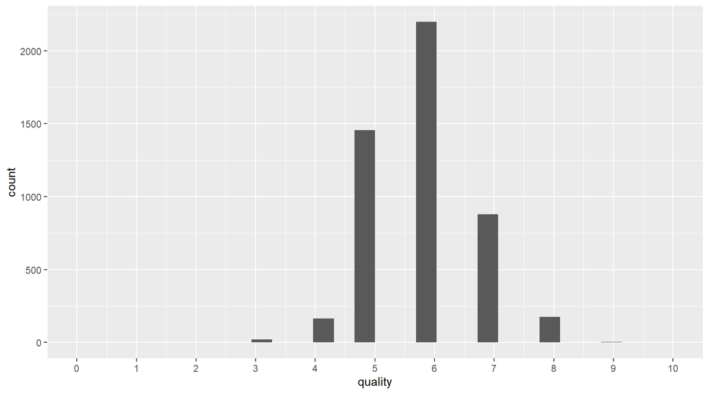

```
## [1] 1640
```

1,640 white wines were received a rating less than 6.

```
## [1] 2198
```

2,198 white wines were received a rating exactly equal to 6.

```
## [1] 1060
```

1,060 white wines were received a rating more than 6. A 6 rating seems about average. Were there any exceptional wine ratings? The numbers do not have any meaning by themselves. Lets change that.

Below shows rating information where a quality score of 0-4 is “Poor”, 5-6 is “Good”, 7-9 is “Very Good”, and 10 is “Exceptional”.

```
##
##        Poor        Good   Very Good Exceptional
##         183        3655        1060           0
```

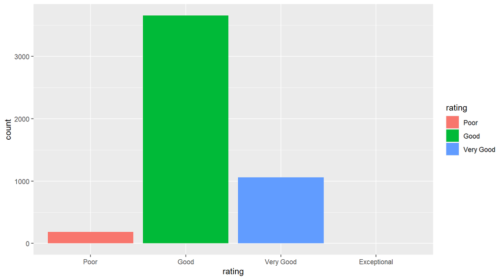

Based of this rating scheme, most wines were good, few were poor, and no wines had a perfect score of 10.

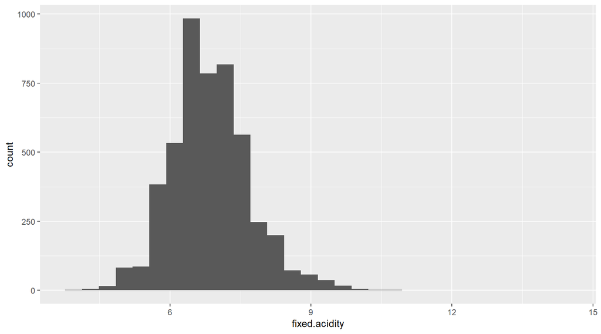

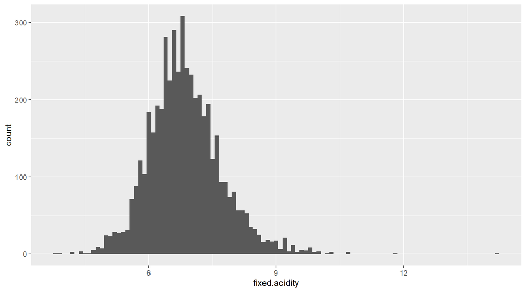

The fixed acidity seems to have a normal distribution but, some fixed, acidity levels seem more common than others. There also a few outliers where values are closer to zero or greater than 9.

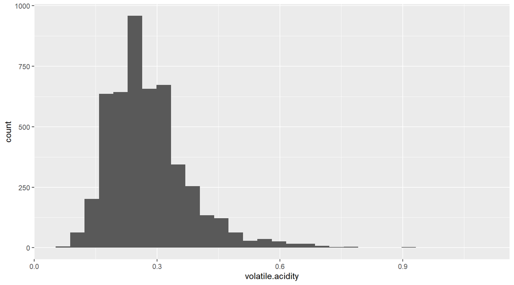

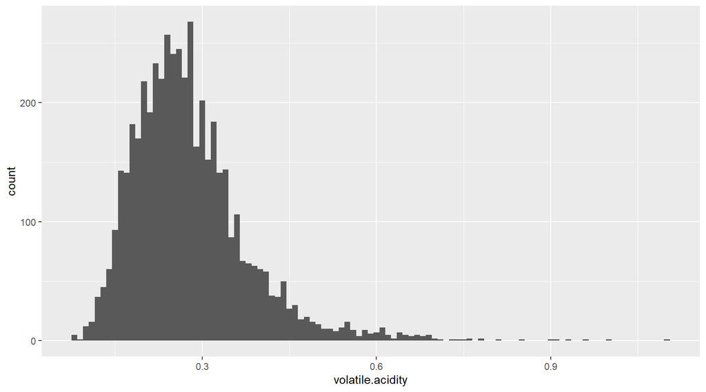

Volatile acidity is skewed to the right.

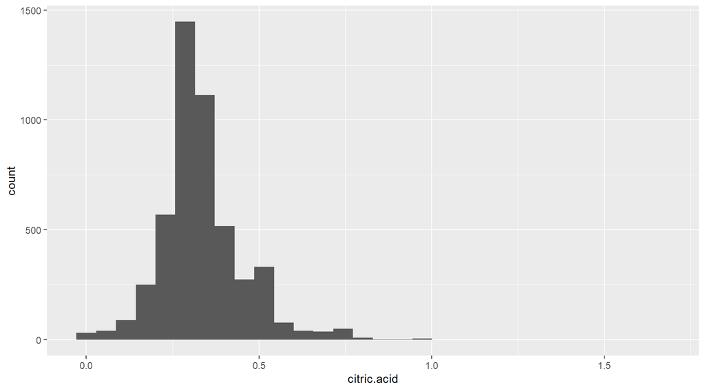

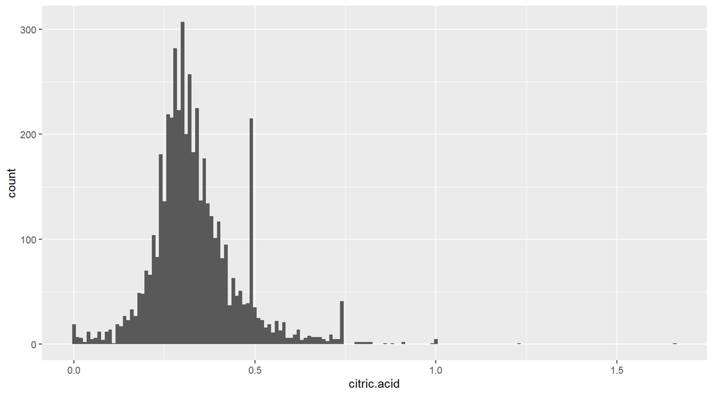

The citric acid plot is also has a fairly normal distribution.

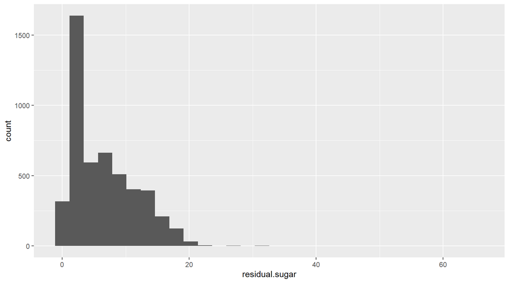

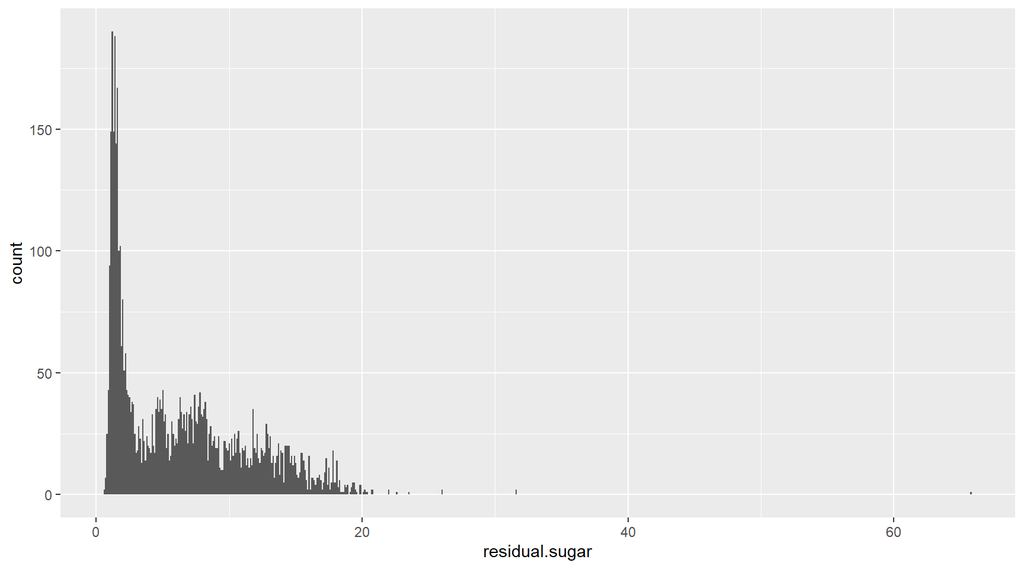

```
##    Min. 1st Qu.  Median    Mean 3rd Qu.    Max.
##   0.600   1.700   5.200   6.391   9.900  65.800
```

```
##
##   0.6   0.7   0.8   0.9  0.95     1  1.05   1.1  1.15   1.2  1.25   1.3  1.35
##     2     7    25    39     4    93     1   146     3   187     3   147     2
##   1.4  1.45   1.5  1.55   1.6  1.65   1.7  1.75   1.8  1.85   1.9  1.95     2
##   184     4   142     2   165     2    99     1    99     3    59     2    79
##  2.05   2.1   2.2  2.25   2.3  2.35   2.4   2.5   2.6  2.65   2.7   2.8  2.85
##     1    51    56     2    42     1    41    40    33     1    38    36     1
##   2.9     3   3.1  3.15   3.2   3.3   3.4   3.5   3.6   3.7  3.75   3.8  3.85
##    25    17    17     1    28    23    13    31    22    12     2    21     3
##   3.9  3.95     4   4.1   4.2  4.25   4.3  4.35   4.4  4.45   4.5  4.55   4.6
##    17     3    19    17    31     2    19     1    14     3    33     2    40
##   4.7  4.75   4.8  4.85   4.9     5   5.1  5.15   5.2  5.25   5.3  5.35   5.4
##    29     5    38     1    35    43    28     2    29     4    17     2    23
##  5.45   5.5  5.55   5.6   5.7   5.8  5.85   5.9  5.95     6   6.1   6.2   6.3
##     2    13     1    16    30    23     2    19     1    23    21    31    39
##  6.35   6.4   6.5  6.55   6.6  6.65   6.7  6.75   6.8  6.85   6.9  6.95     7
##     1    34    26     1    30     3    25     1    28     6    20     1    31
##  7.05   7.1   7.2  7.25   7.3  7.35   7.4  7.45   7.5   7.6   7.7  7.75   7.8
##     2    36    29     2    19     2    40     1    30    29    34     2    41
##  7.85   7.9  7.95     8   8.1  8.15   8.2  8.25   8.3   8.4  8.45   8.5  8.55
##     1    32     1    32    34     1    36     2    31    13     1    24     1
##   8.6  8.65   8.7  8.75   8.8   8.9  8.95     9  9.05   9.1  9.15   9.2  9.25
##    27     1    18     2    22    23     1    18     1    17     2    22     2
##   9.3   9.4   9.5  9.55   9.6  9.65   9.7   9.8  9.85   9.9    10 10.05  10.1
##    11    10     9     1    18     4    22    16     3    18    18     3    14
##  10.2  10.3  10.4  10.5 10.55  10.6 10.65  10.7  10.8  10.9    11  11.1  11.2
##    23    16    25    16     1    22     1    26    17    11    19    18    18
## 11.25  11.3  11.4 11.45  11.5  11.6  11.7 11.75  11.8  11.9 11.95    12 12.05
##     2    12    14     1    11    15     8     4    35    16     3    16     1
##  12.1 12.15  12.2  12.3  12.4  12.5 12.55  12.6  12.7 12.75  12.8 12.85  12.9
##    21     4    15    13    19    16     2    16    16     1    25     4    25
##    13  13.1 13.15  13.2  13.3  13.4  13.5 13.55  13.6 13.65  13.7  13.8  13.9
##    19    23     1    13    16     7    10     3    12     4    21     8    18
##    14 14.05  14.1 14.15  14.2  14.3 14.35  14.4 14.45  14.5 14.55  14.6  14.7
##    16     1     4     1    20    17     3    17     3    17     3    13    14
## 14.75  14.8  14.9 14.95    15  15.1 15.15  15.2 15.25  15.3  15.4  15.5 15.55
##     2    12    14     2    13     7     1     6     1     9    17    11     6
##  15.6  15.7 15.75  15.8  15.9    16 16.05  16.1  16.2  16.3  16.4 16.45  16.5
##    14     9     1     6     2    10     6     2     7     7     5     1     3
## 16.55  16.6 16.65  16.7 16.75  16.8 16.85  16.9 16.95    17 17.05  17.1  17.2
##     1     2     5     5     2     4     4     3     3     1     1     5     9
##  17.3 17.35  17.4 17.45  17.5 17.55  17.6  17.7 17.75  17.8 17.85  17.9 17.95
##    14     1     2     2     8     3     2     1     4    13     5     2     3
##    18 18.05  18.1 18.15  18.2  18.3 18.35  18.4  18.5  18.6 18.75  18.8  18.9
##     2     3     6     8     3     2     4     1     1     1     4     3     1
## 18.95  19.1 19.25  19.3 19.35  19.4 19.45  19.5  19.6  19.8  19.9 19.95 20.15
##     3     1     3     4     1     2     3     2     1     4     1     3     1
##  20.2  20.3  20.4  20.7  20.8    22  22.6  23.5 26.05  31.6  65.8
##     2     1     1     2     2     2     1     1     2     2     1
```

The summary shows a large range of values for residual sugar. 75% of values are below 9.9. The table shows that there is only one wine with a 65.8 value for residual sugar. The next highest level is at 31.6. Does sweetness have an impact on quality ratings?

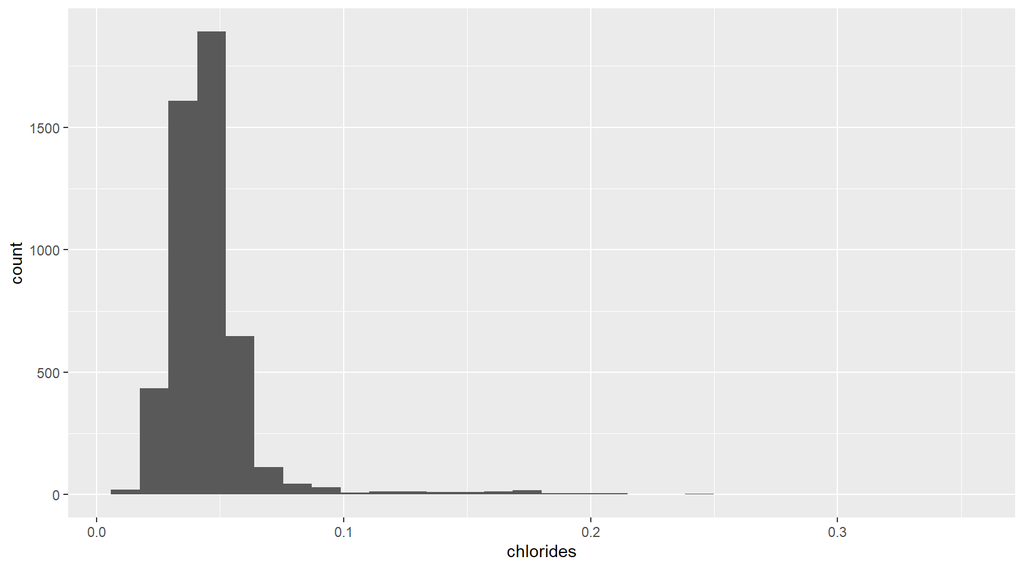

```
##    Min. 1st Qu.  Median    Mean 3rd Qu.    Max.
## 0.00900 0.03600 0.04300 0.04577 0.05000 0.34600
```

Chlorides which are the salt content in wine seem to be relatively low. 75% of values fall under .05 and the middle 50% of values are in the range of .036 to .05. However, the data skews to the right with a few values that are significantly higher. Would this affect the quality ratings? How much salt is too much?

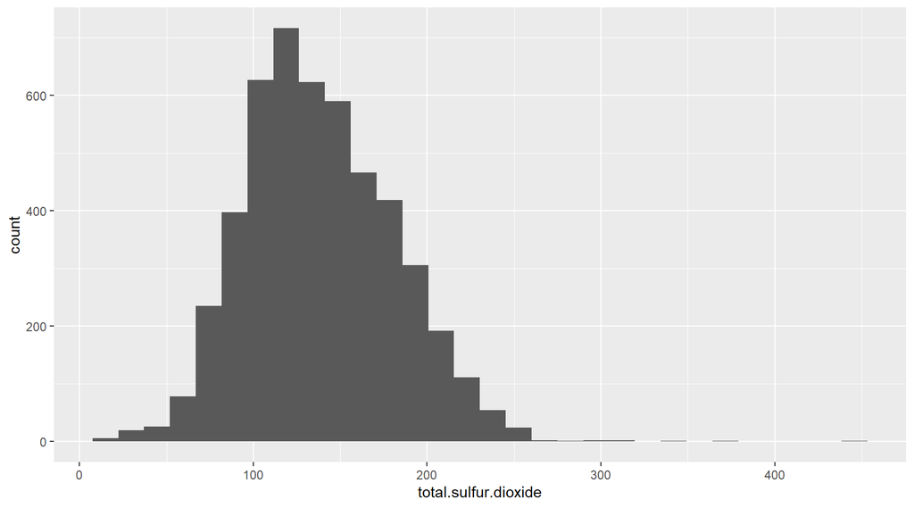

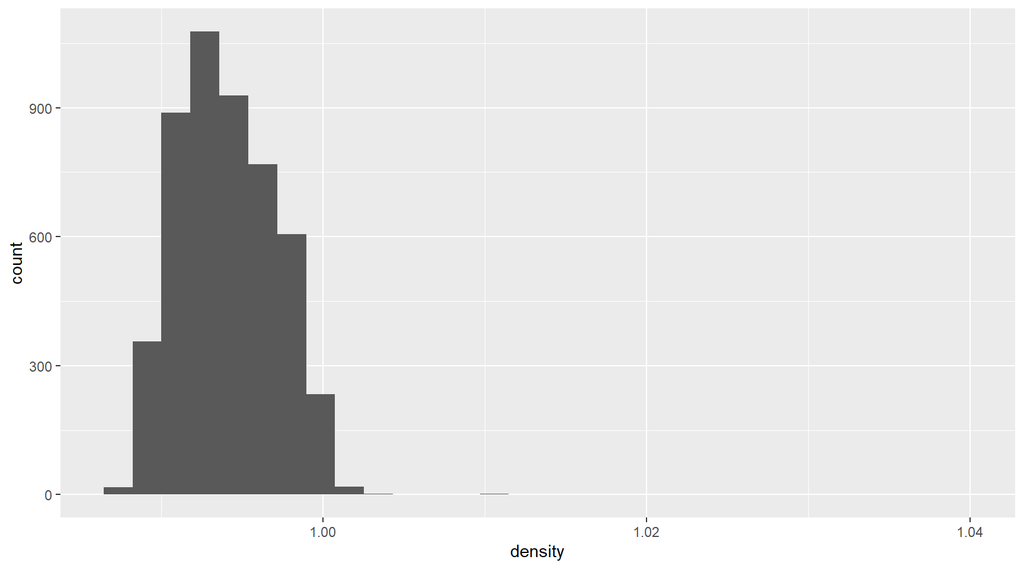

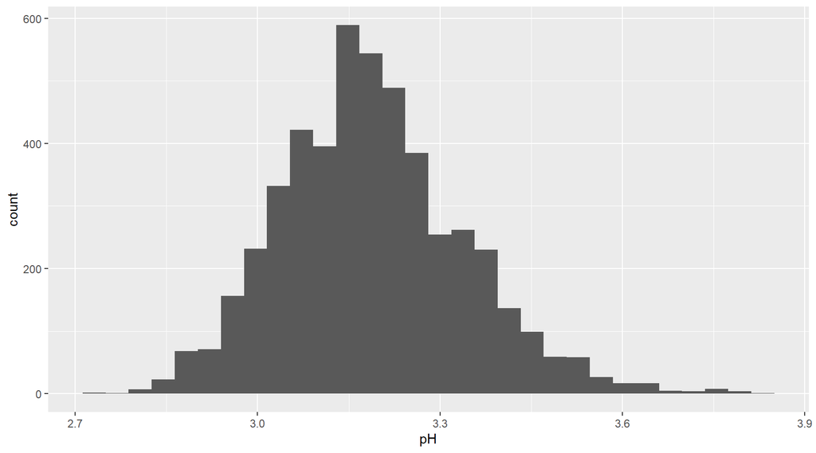

Most wines are stated have pH levels between 3.0 and 4.0. This plot shows this to be true although there is a small portion of wines that are more acidic at pH levels below 3.0. It would be interesting to see if this difference that seems small makes an impact on quality ratings.

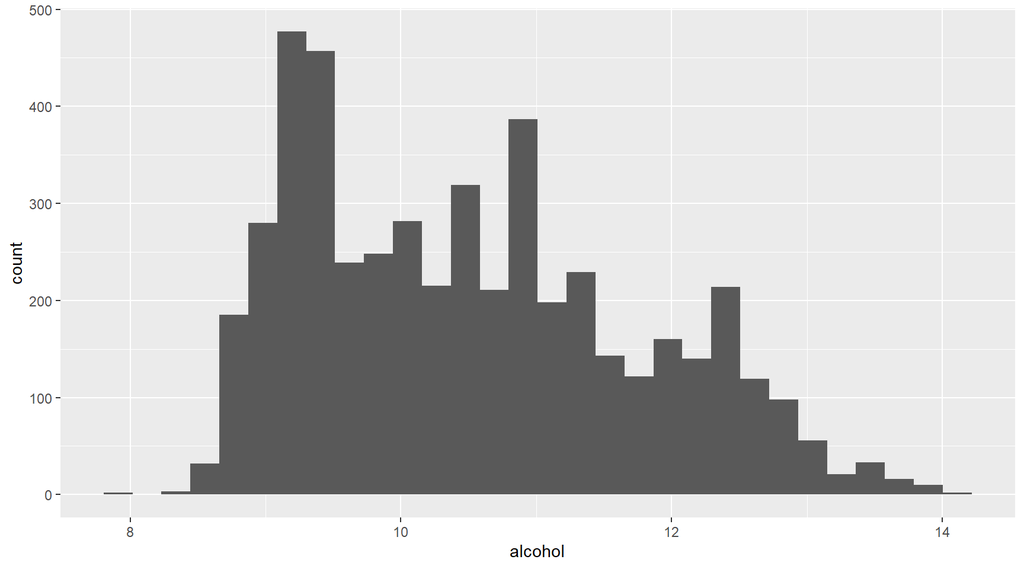

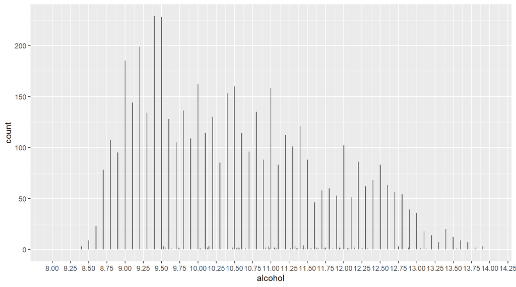

There generally seems to be less wines in the count as the alcohol content increases. Some spikes in the plot may be due to the value of the alcohol content being a whole number. Although other common numbers seem to be those ending in .5.

# Univariate Analysis

### Dataset Structure

This data set consists of 4,898 wines. Each wine has 11 attributes and 1 quality rating associated with it.

- 1 - fixed acidity (tartaric acid - g / dm^3)
- 2 - volatile acidity (acetic acid - g / dm^3)
- 3 - citric acid (g / dm^3)
- 4 - residual sugar (g / dm^3)
- 5 - chlorides (sodium chloride - g / dm^3
- 6 - free sulfur dioxide (mg / dm^3)
- 7 - total sulfur dioxide (mg / dm^3)
- 8 - density (g / cm^3)
- 9 - pH
- 10 - sulfates (potassium sulfate - g / dm^3)
- 11 - alcohol (% by volume)
- 12 - quality (score between 0 and 10)

### Main Features of Interest

Volatile acidity, residual sugar, and alcohol content stand out as variables that could easily impact the the taste and smell of wine. These along with the quality ratings may let us know what makes a decent wine. For the purposes of this analysis, the free sulfur dioxide and sulfates attributes were left out because they seemed similar to the total sulfur dioxide attribute.

### Other Features of Interest

Sulfur dioxide which can be tasted if levels are too high.This could impact quality if detected by the wine testers. Density could also impact scores as it gives wine a different mouth feel.

### New Variables

A rating variable was created from quality scores to give some meaning to the numbers .

### Unusual Distributions

Some chemical components were skewed to the right meaning, there were some outliers where wines had more of chemical in them than most of the other wines. These chemicals were, volatile acid, citric acid, residual sugar, and chlorides which all seem like chemicals that may not be wanted in to large of a quantity.

# Bivariate Plots Section

```
##                           quality fixed.acidity volatile.acidity  citric.acid
## quality               1.000000000   -0.11366283      -0.19472297 -0.009209091
## fixed.acidity        -0.113662831    1.00000000      -0.02269729  0.289180698
## volatile.acidity     -0.194722969   -0.02269729       1.00000000 -0.149471811
## citric.acid          -0.009209091    0.28918070      -0.14947181  1.000000000
## residual.sugar       -0.097576829    0.08902070       0.06428606  0.094211624
## chlorides            -0.209934411    0.02308564       0.07051157  0.114364448
## total.sulfur.dioxide -0.174737218    0.09106976       0.08926050  0.121130798
## pH                    0.099427246   -0.42585829      -0.03191537 -0.163748211
## density              -0.307123313    0.26533101       0.02711385  0.149502571
## alcohol               0.435574715   -0.12088112       0.06771794 -0.075728730
##                      residual.sugar   chlorides total.sulfur.dioxide
## quality                 -0.09757683 -0.20993441         -0.174737218
## fixed.acidity            0.08902070  0.02308564          0.091069756
## volatile.acidity         0.06428606  0.07051157          0.089260504
## citric.acid              0.09421162  0.11436445          0.121130798
## residual.sugar           1.00000000  0.08868454          0.401439311
## chlorides                0.08868454  1.00000000          0.198910300
## total.sulfur.dioxide     0.40143931  0.19891030          1.000000000
## pH                      -0.19413345 -0.09043946          0.002320972
## density                  0.83896645  0.25721132          0.529881324
## alcohol                 -0.45063122 -0.36018871         -0.448892102
##                                pH     density     alcohol
## quality               0.099427246 -0.30712331  0.43557472
## fixed.acidity        -0.425858291  0.26533101 -0.12088112
## volatile.acidity     -0.031915368  0.02711385  0.06771794
## citric.acid          -0.163748211  0.14950257 -0.07572873
## residual.sugar       -0.194133454  0.83896645 -0.45063122
## chlorides            -0.090439456  0.25721132 -0.36018871
## total.sulfur.dioxide  0.002320972  0.52988132 -0.44889210
## pH                    1.000000000 -0.09359149  0.12143210
## density              -0.093591493  1.00000000 -0.78013762
## alcohol               0.121432099 -0.78013762  1.00000000
```

There seems to be a strong correlations between density vs alcohol and density vs residual sugar but, lets investigate this another way.

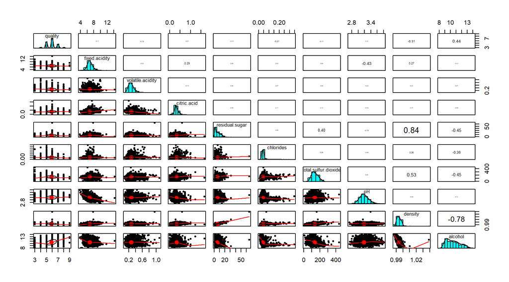

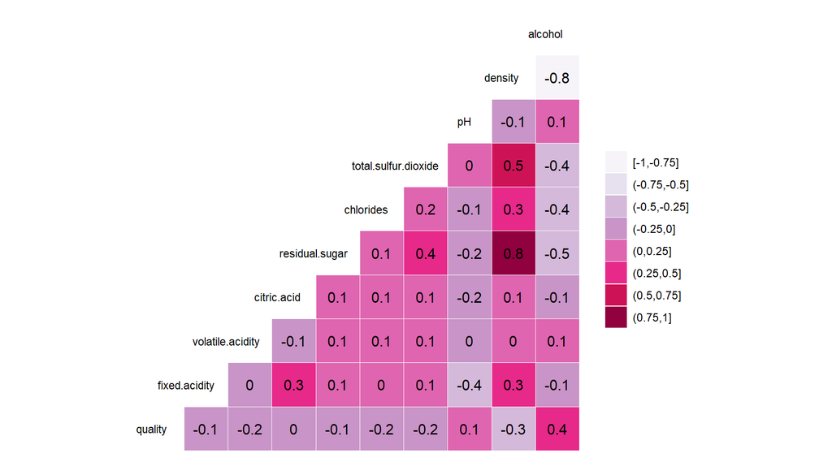

Each plot makes it easier to see that there seems to be a negative correlation between alcohol and density and a positive correlation between residual sugar and density. This would makes sense because more liquids in a wine should make wine thinner than as opposed to sugar which would make the wine thicker or more syrupy.

Water has a density of approximately 1 g/cm^3. Density compared to residual sugars and alcohol will be interesting to explore.

Quality seems to be the most affected by density and alcohol content.

Let’s begin our exploration of residual sugar, alcohol, and density.

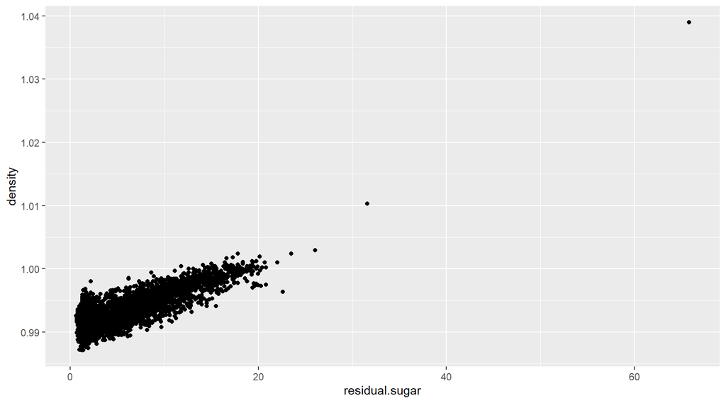

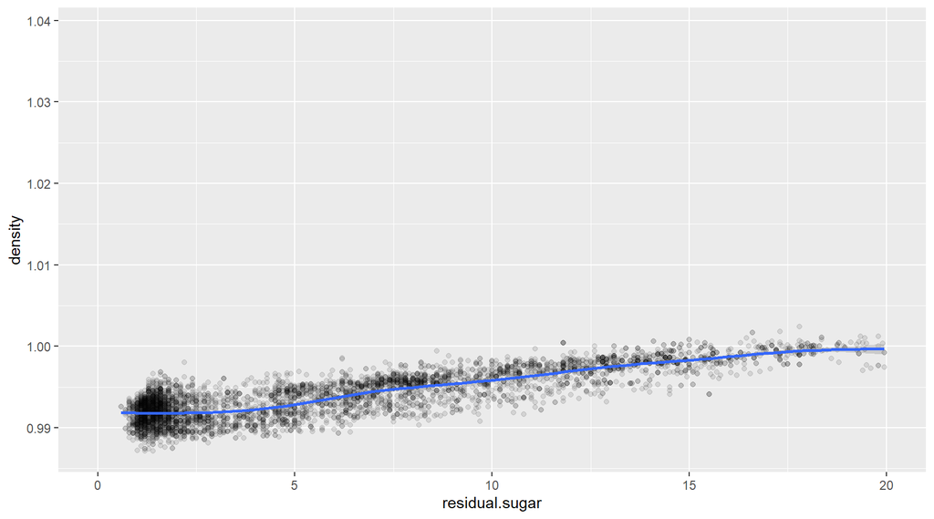

Most wines have a density less than water when looking at how much sugar is left in the wine. The wines that noticeably surpass the density of water are the outliers. After zooming in on the data, very few wines have a density of greater than 1.

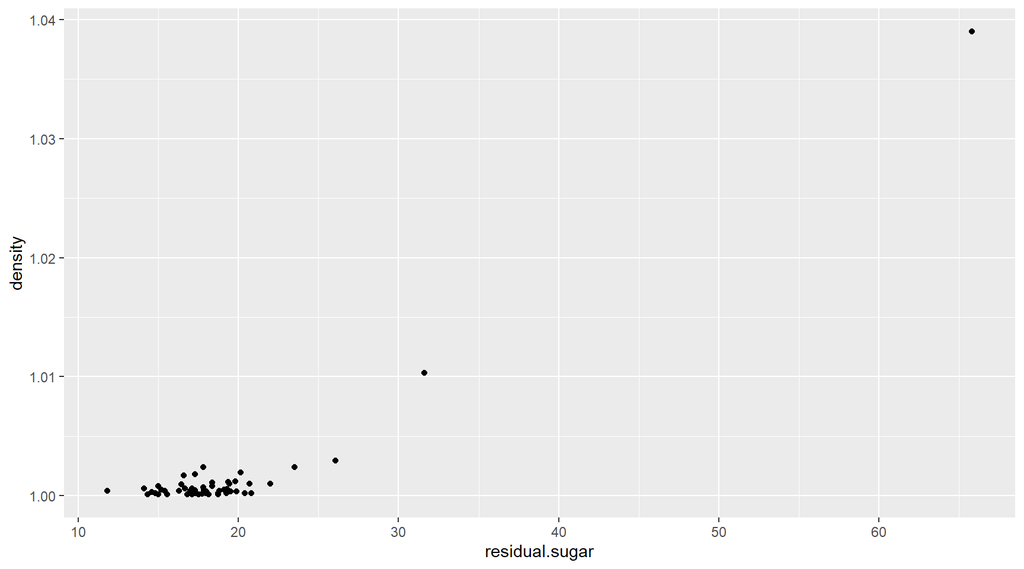

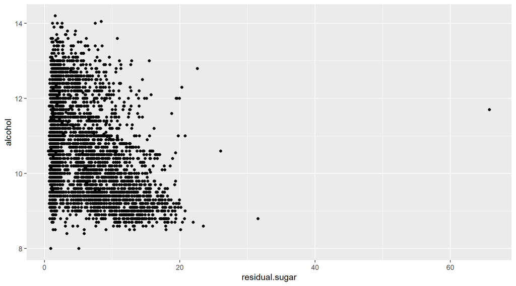

```
## [1] -0.4506312
```

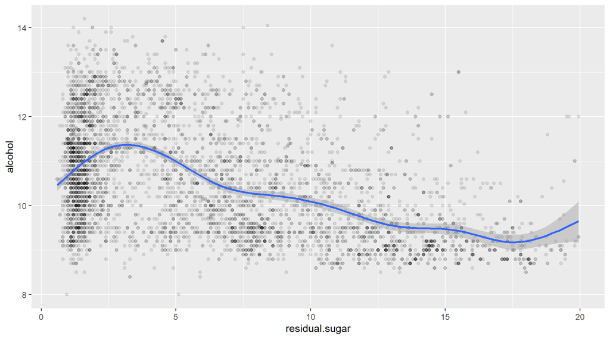

There does seem to be a somewhat of a correlation between sugar and alcohol content where wines with more sugar have less alcohol content.

```
##
##  Pearson's product-moment correlation
##
## data:  less.sugar$residual.sugar and less.sugar$alcohol
## t = -36.307, df = 4878, p-value < 2.2e-16
## alternative hypothesis: true correlation is not equal to 0
## 95 percent confidence interval:
##  -0.4830522 -0.4388673
## sample estimates:
##        cor
## -0.4612457
```

Checking the correlation without white wines with residual sugar greater than 20, it did increase some. We’ll be conduct all further analysis pertaining to wines with residual sugar to those under 20 grams/dm^3.

How do these attributes compare with quality ratings?

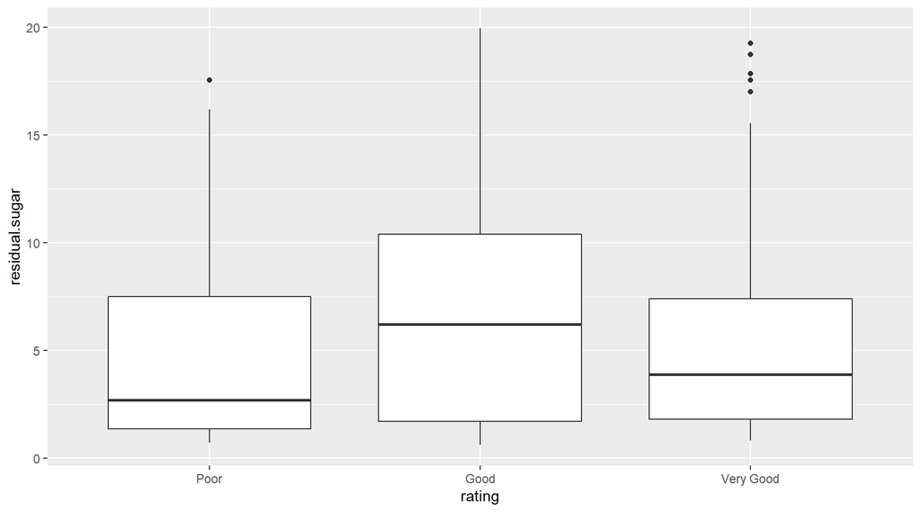

```
## # A tibble: 3 x 4
##   rating    sugar_mean sugar_median     n
##   <fct>          <dbl>        <dbl> <int>
## 1 Poor            4.82         2.7    183
## 2 Good            6.71         6.2   3637
## 3 Very Good       5.26         3.88  1060
```

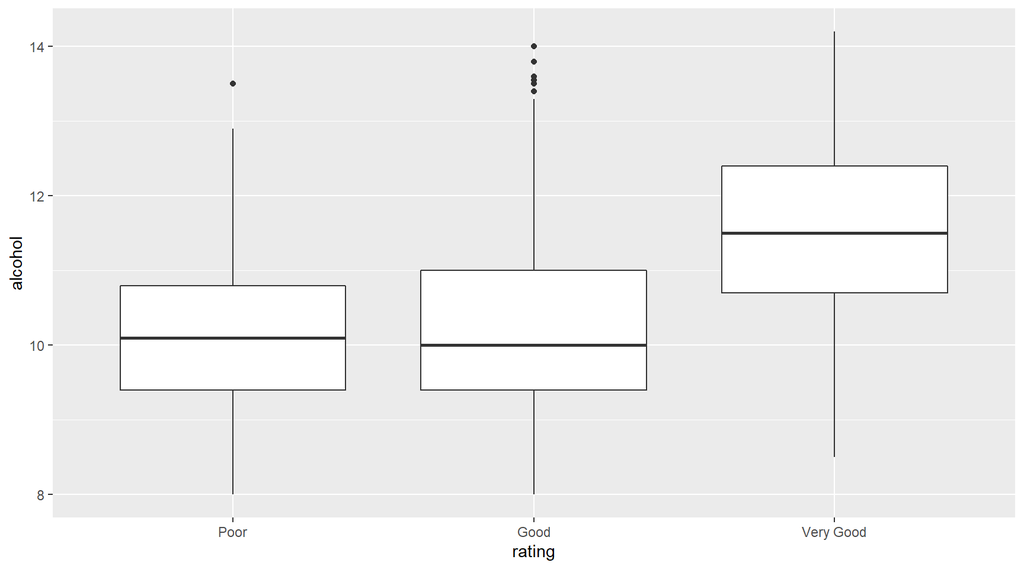

```
## # A tibble: 3 x 4
##   rating    alcohol_mean alcohol_median     n
##   <fct>            <dbl>          <dbl> <int>
## 1 Poor              10.2           10.1   183
## 2 Good              10.3           10    3655
## 3 Very Good         11.4           11.5  1060
```

“Very Good” alcohol seems to have slightly more alcohol than the others.

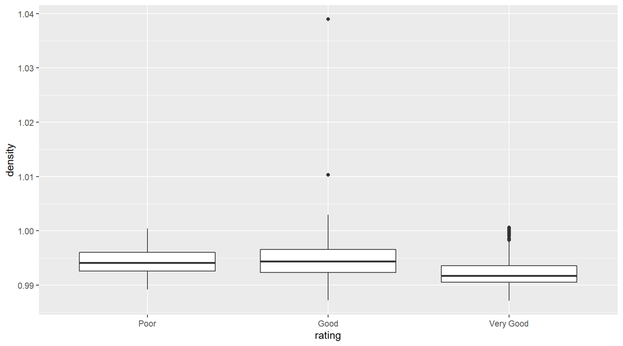

```
## # A tibble: 3 x 4
##   rating    density_mean density_median     n
##   <fct>            <dbl>          <dbl> <int>
## 1 Poor             0.994          0.994   183
## 2 Good             0.994          0.994  3655
## 3 Very Good        0.992          0.992  1060
```

The difference in wine density is extremely small but, “Very Good” wine is still slightly less thick than “Poor” and “Good”.

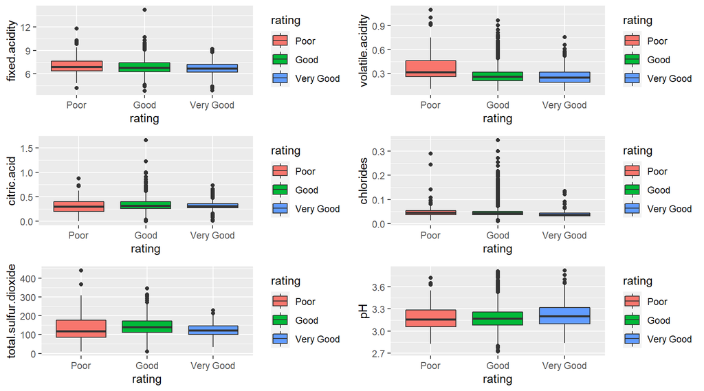

There are quite a few outliers making these plots hard to see.

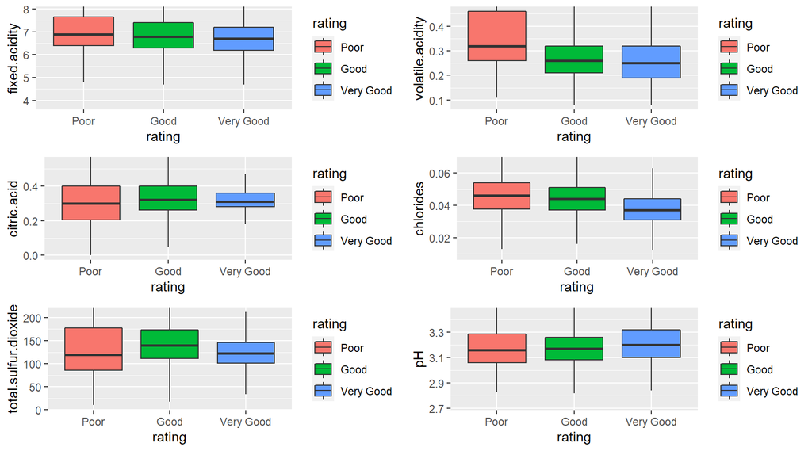

After removing the outliers from these plots, it looks as if the following is preferred to get a “Very Good” rating:

- Lower amounts of fixed acidity, volatile acidity, and chlorides
- A higher pH

Let’s confirm. What if we looked at these closer by comparing these attributes with numeric quality ratings?

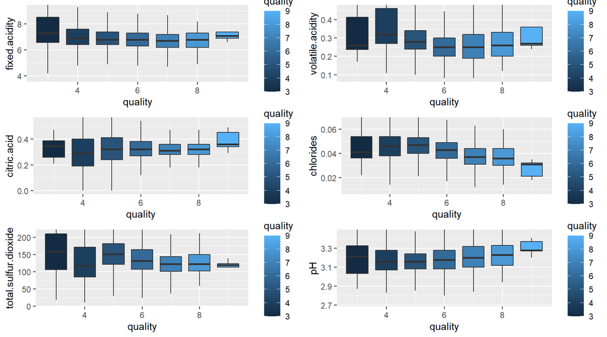

Just by looking at these plots, the highest rated white wines still have lower amounts of chlorides and higher pH levels. They also have a higher levels of fixed acidity and citric acid which doesn’t align with the previous box plots that are grouped into ratings.

```
##                              [,1]
## fixed.acidity        -0.113662831
## volatile.acidity     -0.194722969
## citric.acid          -0.009209091
## chlorides            -0.209934411
## total.sulfur.dioxide -0.174737218
## pH                    0.099427246
```

The most significant correlation is chlorides. The amount of chlorides in wine decreases as ratings increase.

# Bivariate Analysis

# Multivariate Plots Section

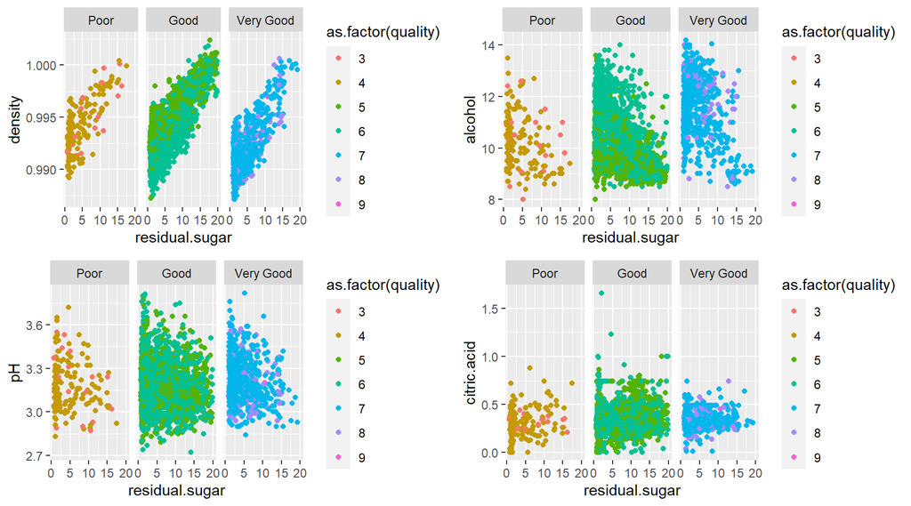

The relationship between residual sugar and density by rating and quality shows a positive correlation.

The negative correlation between residual sugar and alcohol by rating and quality can also be seen although it is not as strong.

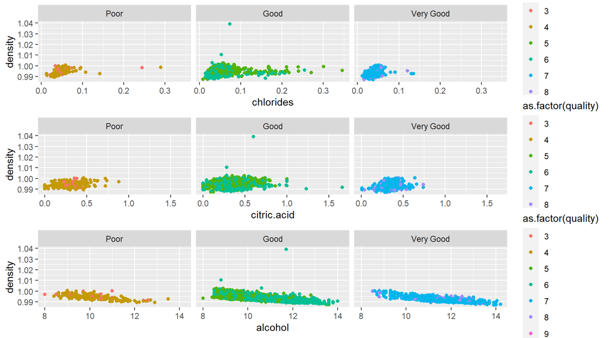

There seems to be a slight correlation between chlorides and density by quality and rating. The relationship is not strong but, wines rated “Poor” and “Good” have more wines with higher levels of chlorides than wines rated “Very Good”.

Citric acid does not seem to have an impact on density but, some of the highest rated wines do have more citric acid than than those rated lower.

Higher levels of alcohol make wine less dense and seem to contribute to better quality scores and ratings.